# Лабораторная работа №7

Дисциплина: Администрирование сетевых подсистем

Бахи сиди али темассини

1032234211@pfur.ru

Российский университет дружбы народов

2026-02-16

# Цель работы

## Цель работы

- Получение навыков настройки межсетевого экрана в Linux
- Реализация переадресации портов
- Настройка Masquerading

# Выполнение лабораторной работы

## Создание пользовательской службы firewalld

- Выполнен переход в режим суперпользователя
- Скопирован файл `ssh.xml` в `ssh-custom.xml`
- Файл размещён в `/etc/firewalld/services/`

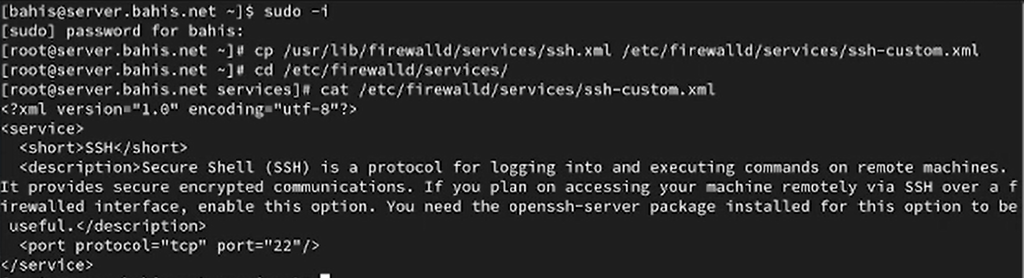

Рисунок 1: Копирование файла службы ssh.xml в ssh-custom.xml

- В файле изменён порт с `22` на `2022`
- Обновлено описание службы
- Проверено содержимое файла

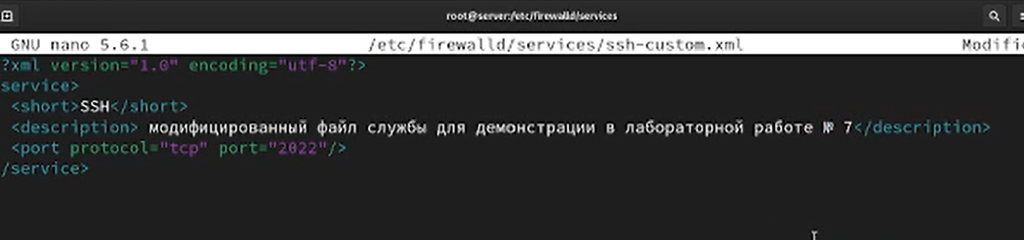

Рисунок 2: Редактирование службы: изменение порта на 2022 и обновление описания

- Получен список служб `--get-services`
- Выполнена перезагрузка `firewall-cmd --reload`
- Служба `ssh-custom` добавлена в активные
- Добавлена в постоянную конфигурацию

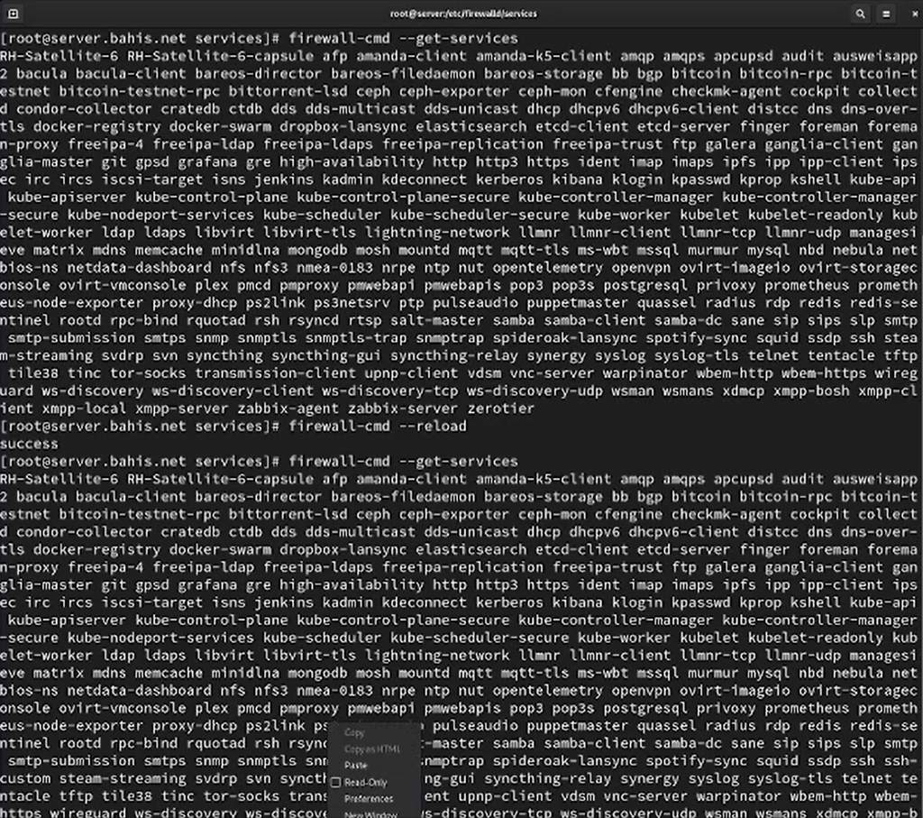

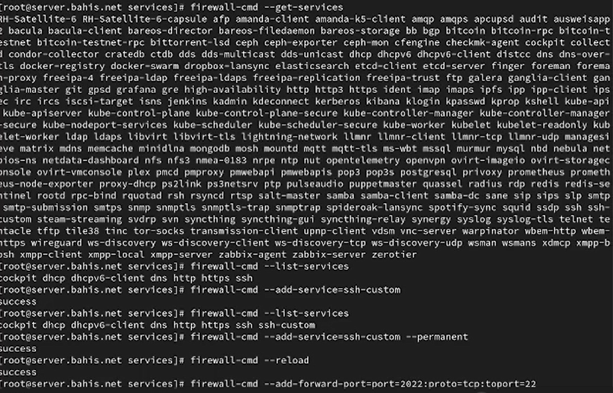

Рисунок 4: Добавление и активация пользовательской службы ssh-custom в firewalld

## Перенаправление портов

- Настроено правило перенаправления:
- `2022 → 22` (TCP)
- Правило добавлено в текущую конфигурацию

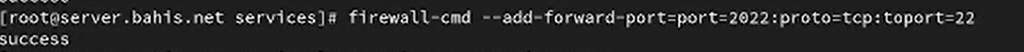

Рисунок 5: Настройка перенаправления порта 2022 на 22 в firewalld

- С клиента выполнено подключение:
- `ssh -p 2022 @server.bahis.net`
- Подтверждена успешная авторизация
- Проверена работа перенаправления

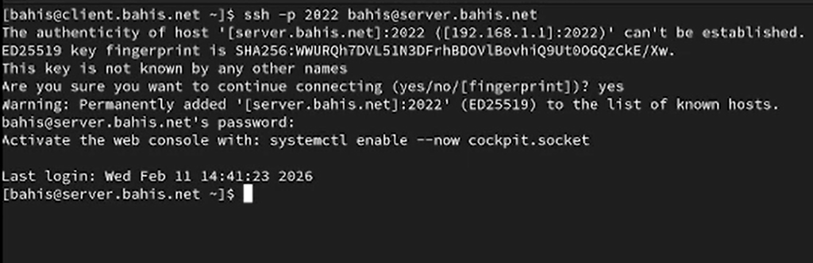

Рисунок 6: Подключение по SSH к серверу через порт 2022 с клиента

- Проверен параметр `net.ipv4.ip_forward`
- Значение — `0` (маршрутизация отключена)

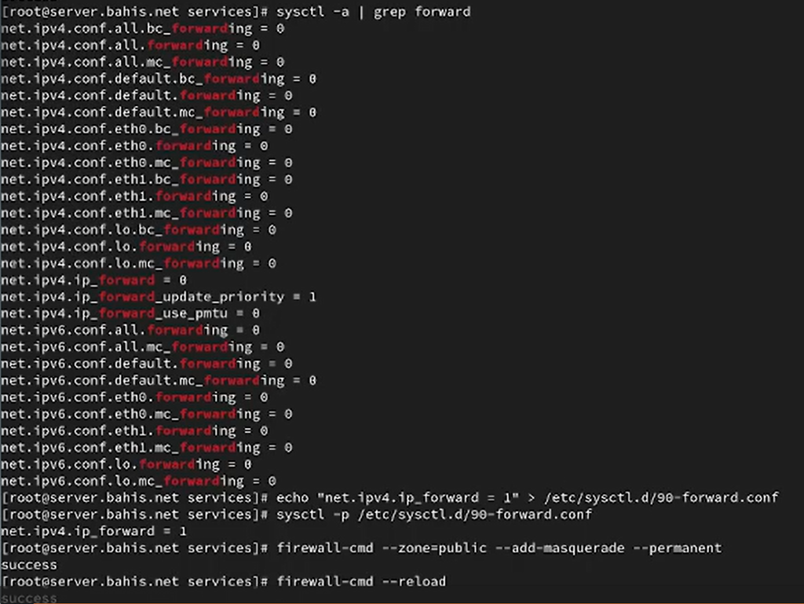

Рисунок 7: Проверка параметров пересылки IPv4 в ядре системы

- Создан файл `/etc/sysctl.d/90-forward.conf`
- Установлено `net.ipv4.ip_forward = 1`
- Применена конфигурация `sysctl -p`
- Включён masquerade в зоне `public`
- Выполнен `firewall-cmd --reload`

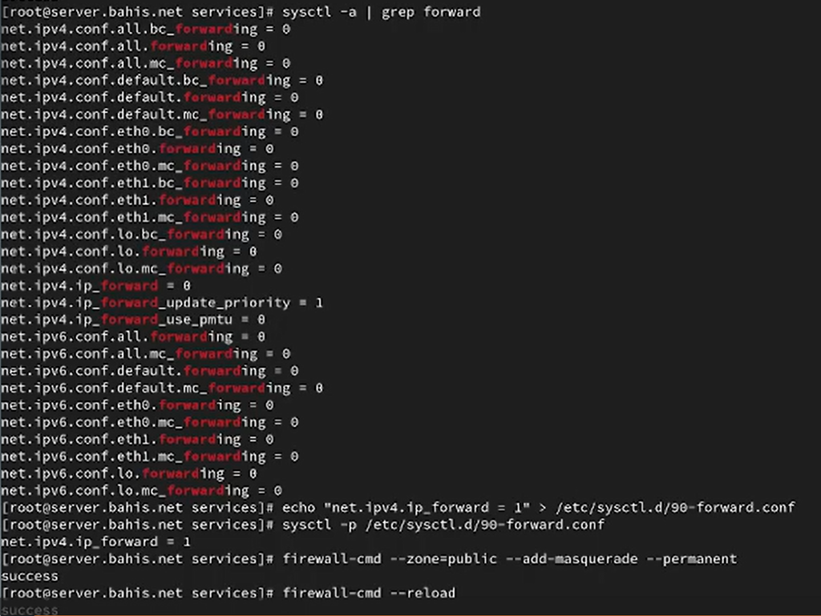

Рисунок 8: Проверка параметров пересылки IPv4 в ядре системы

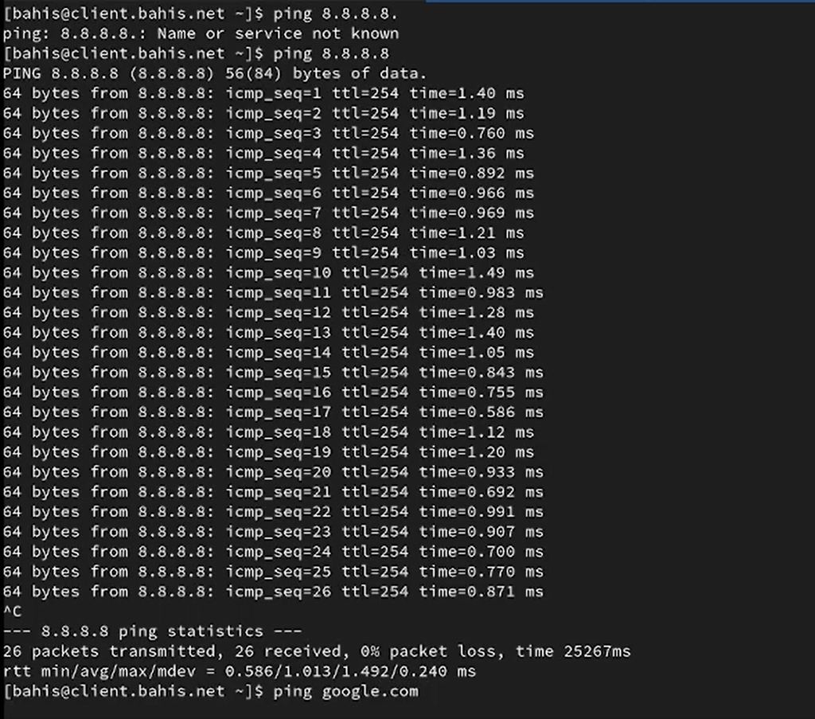

Рисунок 9: Проверка доступа в Интернет с клиента после включения IP-forward и masquerade

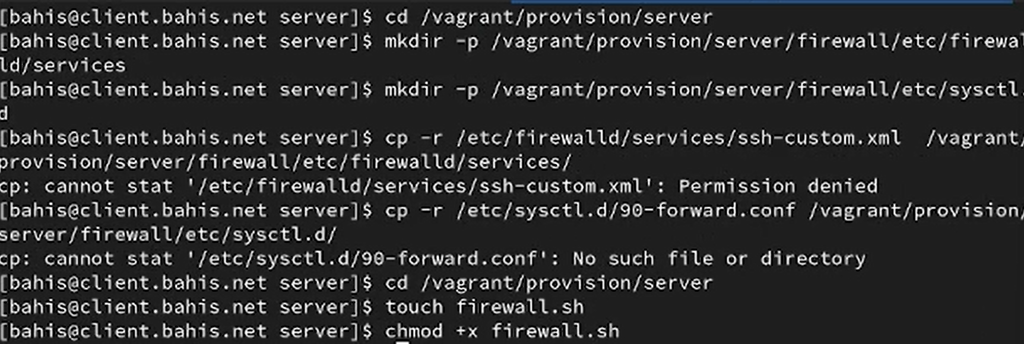

- Создан скрипт `firewall.sh`
- Реализовано:
- копирование конфигураций в `/etc`
- добавление службы `ssh-custom`
- перенаправление `2022 → 22`
- включение masquerade
- перезагрузка firewalld
- восстановление SELinux-контекстов

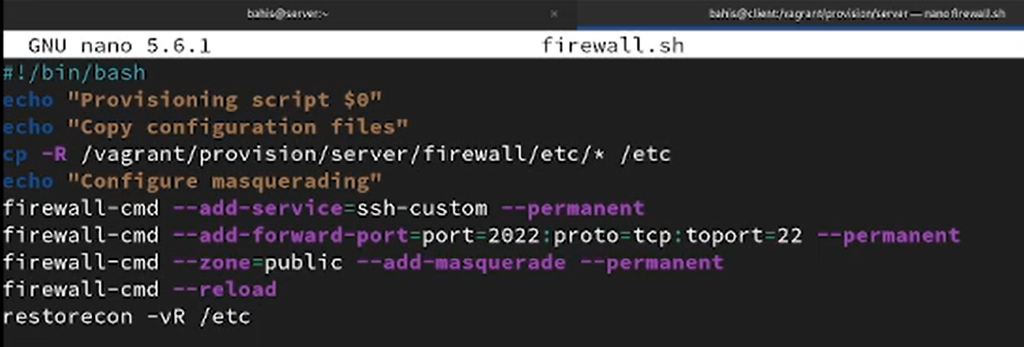

Рисунок 11: Содержимое provisioning-скрипта firewall.sh

- В `Vagrantfile` добавлен provision-блок
- Тип `shell`
- Путь `provision/server/firewall.sh`
- Указан `preserve_order: true`

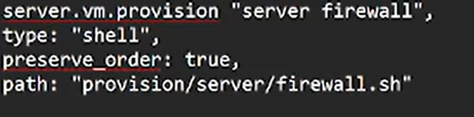

Рисунок 12: Добавление provisioning-скрипта firewall.sh в Vagrantfile

# Выводы

## Выводы

- Создана пользовательская служба `ssh-custom` (порт 2022)
- Реализовано перенаправление `2022 → 22`
- Подтверждён SSH-доступ через нестандартный порт
- Включена маршрутизация IPv4 (`ip_forward = 1`)
- Настроен masquerading в зоне `public`
- Подтверждён выход клиента в Интернет через сервер
- Реализована автоматизация через `firewall.sh` и `Vagrantfile`